# Temporal Classifier using TensorFlow for Human Pancreatic Cells

Sumeet Pal Singh

September 12, 2017

## Classification of human pancreatic cells

This is an R Markdown document (http://rmarkdown.rstudio.com) detailing the steps for building the age classifier for human pancreatic cells. The data comes from Enge et al. Cell, Volume 171 , Issue 2 , 321 - 330, September, 2017

Human pancreatic cells were collected from three stages: juvenile (ages 1 month, 5 years and 6 years), young adult (ages 21 and 22 years) and adult/middle aged (ages 38, 44 and 54 years)

From each stage, individual pancreatic cells were collected in 96-well plates and sequenced.

The document starts with compiled RPM values. RPM values were generated using the read counts provided at Gene Expression Omnibus (GEO), accession number GSE81547. https://www.ncbi.nlm.nih.gov/geo/query/acc.cgi?acc=GSE81547 RPM value calculation is performed in counts_rpm.R file.

We will build a classifier using Deep Neural Network (DNN) that separates individual cells into the three age groups:

1 month, 5 years, 6 years: Juvenile ### Please note that the sample sheet provided online, and the labeling of the samples label 1 month cells as ### 1yr. Hence, we use 1yr here as the label. But this must be a typo in the sample lables.

21 years, 22 years: Young

38 years, 44 years, 54 years: Middle

The DNN is build using TensorFlow library.

```r
library(tensorflow)
library(caret)
## Load all files in source/ folder that contail useful functions
sapply(list.files(pattern="[.]R$", path="source", full.names=TRUE, recursive = F), source)
```

**Loading the Data**

Data contains genes as rows, and samples as columns.

```r
## Choose the data file
myData = read.table(file = "Enge_RPM.csv", sep = ",", header = T, row.names = 1, check.names = F)

## Sanity Check: Look at the number of samples and number of genes in the complete data
# Dimensions of the uploaded Data
dim(myData)
```

```
## [1] 23460  2544
```

```r
# The first dimension (rows) will equal to the number of genes that were used for mapping.
# The second dimension (columns) will equal to the number of single-cells
```

**Set Stages**

We will set the stages of the cells

```r
## Extract name from column name
myTimeString = regmatches(colnames(myData),regexpr("[0-9A-Za-z]+",colnames(myData)))
head(myTimeString)
```

```
## [1] "21yr" "21yr" "21yr" "21yr" "21yr" "21yr"
```

```r
## Define the parametes for ages in sample
## mySampleAges is the age of each sample, as factor
## myTimePeriod is the period of time used: hour/day/month/year/mpf
## myTimePoints are the discrete time points present in the samples
mySampleAges = as.factor(as.numeric(regmatches(myTimeString,regexpr("[0-9]+",myTimeString))))
head(mySampleAges)
```

```
## [1] 21 21 21 21 21 21
## Levels: 1 5 6 21 22 38 44 54
```

```r
myTimePeriod = regmatches(myTimeString[1],regexpr("[A-Za-z]+",myTimeString[1]))
## Please note that the 1 month sample is labeled as 1 yr online, and we continue to use that.
myTimePeriod
```

```
## [1] "yr"
```

```r
myTimePoints = levels(mySampleAges)

print(paste("The data contains",ncol(myData),"samples from",nlevels(mySampleAges),"time points, from", min(as.numeric(myTimePoints)),myTimePeriod,"to",max(as.numeric(myTimePoints)),myTimePeriod))
```

```
## [1] "The data contains 2544 samples from 8 time points, from 1 yr to 54 yr"
```

**Set classification Stages**

*Important to set these correctly for the success of classifier*

We will set the three classification stages. This will club certain ages into single stage

```r
## In here, we will set the stage of each discrete time point.
## We have eight time points: 1 month (labeled year), 5, 6, 21, 22, 38, 44, 54 years
## 1 month (labeled year), 5, 6 years is set to 'Juvenile'
## 21 and 22 years is set to 'Young'
## 38, 44 and 54 years is set to 'Middle'
Age.labels <- c(rep("Juvenile", 3), rep("Young", 2), rep("Middle", 3))

## We redo the old ages to new stages
## Since this command throws a warning about repeating levels, we will temporally suppress them.
suppressWarnings(Sample.age.conditions <- factor(factor(mySampleAges, labels = Age.labels)))

## And extract the number of conditions (stages). This helps with classification.
myConditions <- factor(Sample.age.conditions, labels = 0:(nlevels(Sample.age.conditions)-1))
myLevels = levels(myConditions)

cat(paste("The data contains ",nlevels(myConditions), "classification stages of: "), paste(myTimePoints, myTimePeriod, ":", Age.labels), sep = "\n")
```

```
## The data contains  3 classification stages of:
## 1 yr : Juvenile
## 5 yr : Juvenile
## 6 yr : Juvenile
## 21 yr : Young
## 22 yr : Young
## 38 yr : Middle
## 44 yr : Middle
## 54 yr : Middle
```

**Building the classifier**

```r
## Now, we will choose the genes that will be used to build the classifier. We will do so by choosing the top most variable genes in the test dataset. Gene selection can also be done based to genes with highest variation, median absolute deviation (MAD), mean, median.

## Choose the variability parameter: "var", "mad", "mean", "median"
myVariance <- "mad"
## Choose the number of parameters (genes) for the model
myTopGenes <- 1000

if (myVariance == "var") {
  vars = apply(log(myData+1),1,var)
} else if (myVariance == "mean") {
  vars = apply(log(myData+1),1,mean)
} else if (myVariance == "median") {
  vars = apply(log(myData+1),1,median)
} else {
  vars = apply(log(myData+1),1,mad)
}

idx = order(vars, decreasing = TRUE)
feat.Selected = idx[1:myTopGenes]
myData.Selected = myData[feat.Selected,]
parameters.name = rownames(myData.Selected)

## A few of the parameters (genes) whose expression values will be used by the model
head(parameters.name)
```

```
## [1] "ABCC8" "INS"   "PDK4"  "CD44"  "SOD2"  "LDHA"
```

**Partitioning the data into test and train set**

```r
## We will partition the data into train and test set for building the classifier
## 80% of data will be used for training. The rest 20% will be kept aside for testing the performance of the model
ratio=0.8
set.seed(171)
n <- ncol(myData.Selected)
ind = unlist(sapply(split(1:length(myConditions), myConditions),
                    function(x) sample(x, size = ratio*length(x), replace = F)),
                    use.names = F)

train.Selected = myData.Selected[,ind]+1
test.Selected = myData.Selected[,-ind]+1

train.cond = myConditions[ind]
test.cond = myConditions[-ind]

train.log = apply(train.Selected, 2, function(x) log(x, 2))
test.log = apply(test.Selected, 2, function(x) log(x, 2))


## To know how the training and test datalooks
table(train.cond)
```

```
## train.cond
##   0   1   2
## 584 632 818
```

```r
table(test.cond)
```

```
## test.cond
##   0   1   2
## 146 159 205
```

**Pick the correct learning rate for the algorithm**

```r
## Too high learning rate
parameters.weights.learn = model_dropout(X_train = train.log, Y_train = train.cond,
                                        num_epochs = 50, learning_rate = 1,
                                        print_cost = T)
```

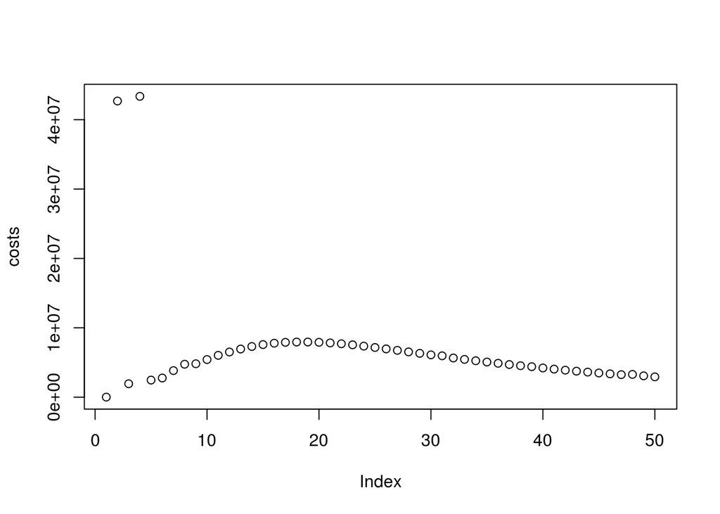

```
## [1] "Accuracy of training set: 0.287118971347809"
```

```r
## Too low learning rate
parameters.weights.learn = model_dropout(X_train = train.log, Y_train = train.cond,
                                         num_epochs = 50, learning_rate = 1e-08,
                                         print_cost = T)
```

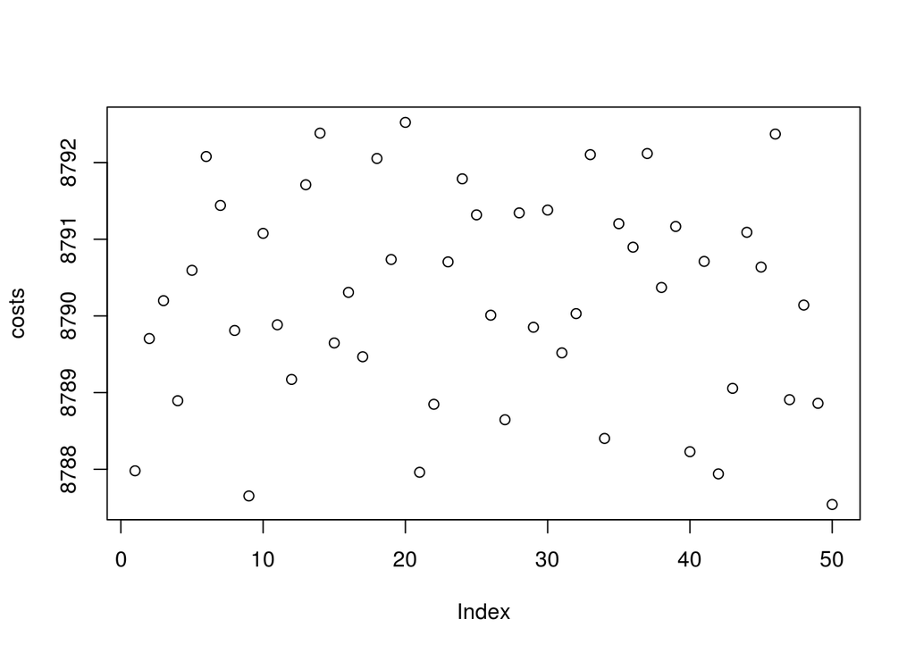

```
## [1] "Accuracy of training set: 0.342674523591995"
```

```r
## Just right learning rate
parameters.weights.learn = model_dropout(X_train = train.log, Y_train = train.cond,
                                         num_epochs = 50, learning_rate = 0.001,
                                         print_cost = T)
```

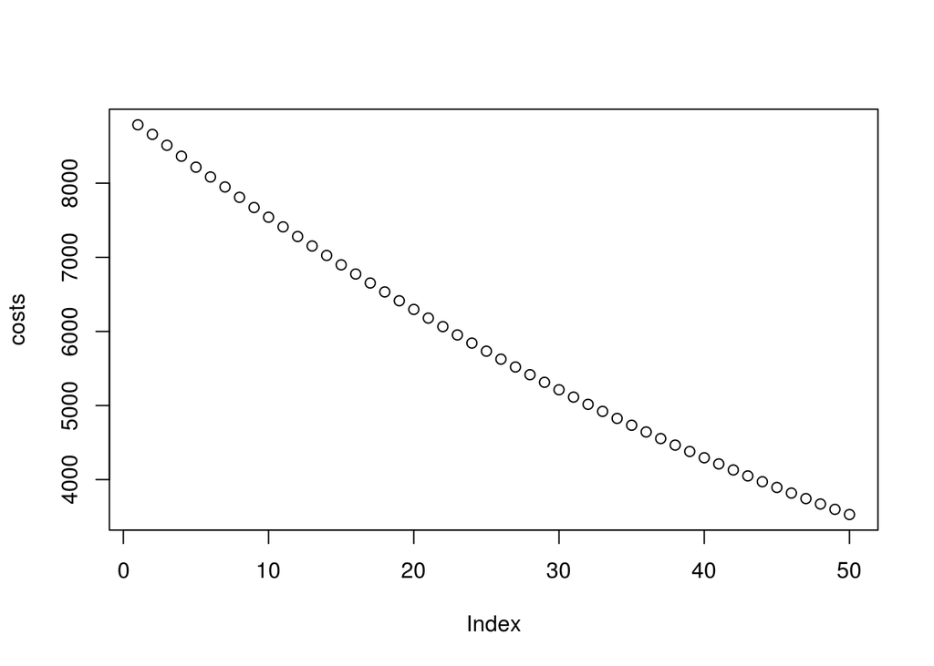

```
## [1] "Accuracy of training set: 0.853490650653839"
```

**Cross-validation for setting hyperparameters**

```r
## To obtain the regularization hyperparameters, we will perform k-fold cross-validation
## We will perfrom 5-fold cross validation repeated 3 times
## The cross validation will be performed over a grid of dropout constant and L2 regularization constant
## droput values will range from 0.4 - 0.9 (6 values)
## Regularization constant values will range from 0.2 - 1.4 in steps of 0.2 (7 values)
nFolds = 5
crossValidation.repeat = 3
dropout.test = seq.int(0.4, 0.9, 0.1)
regularization.test = seq.int (0.2, 1.4, 0.2)
## To save the accuracy of the models
accuracy.models <- matrix(NA, nrow = length(dropout.test), ncol = length(regularization.test))
## We will generate specific seed for each model to enable reproducibility
set.seed(177)
repeat.seeds <- sample(1:1000, crossValidation.repeat)
models.seeds <- array(sample(1:1000, length(accuracy.models)*crossValidation.repeat),
                      dim = c(length(dropout.test), length(regularization.test), crossValidation.repeat))

for (dropout.index in 1:length(dropout.test)){
  for(regularization.index in 1:length(regularization.test)){
    accuracy.repeat = 0
    for(crossValidation.index in 1:crossValidation.repeat){
      # print(models.seeds[dropout.index, regularization.index])
      set.seed(models.seeds[dropout.index, regularization.index, crossValidation.index])
      training.Folds = createFolds(1:ncol(train.log), k = nFolds, list = TRUE, returnTrain = TRUE)
      for(nFolds.index in 1:nFolds){
        train.fold = train.log[,training.Folds[[nFolds.index]]]
        train.cond.fold = train.cond[training.Folds[[nFolds.index]]]
        test.fold = train.log[,-training.Folds[[nFolds.index]]]
        test.cond.fold = train.cond[-training.Folds[[nFolds.index]]]

        parameters.weights.fold = model_dropout(X_train = train.fold, Y_train = train.cond.fold,
                                                num_epochs = 250, learning_rate = 0.001,
                                                regulatization.constant = regularization.test[regularization.index],
                                                dropout.constant = dropout.test[dropout.index],
                                                print_cost = F)
        accuracy.current = prediction_accuracy(test.fold, test.cond.fold, parameters.weights.fold)
        accuracy.repeat = accuracy.repeat + accuracy.current
      }
    }
    accuracy.models[dropout.index, regularization.index] = accuracy.repeat/(crossValidation.repeat * nFolds)
    print(paste("Accuracy for dropout", dropout.test[dropout.index],
                ", regularization", regularization.test[regularization.index],
                "is:", accuracy.models[dropout.index, regularization.index]))
  }
}
```

```
## [1] "Accuracy for dropout 0.4 , regularization 0.2 is: 0.933965424685506"
## [1] "Accuracy for dropout 0.4 , regularization 0.4 is: 0.936417295037985"
## [1] "Accuracy for dropout 0.4 , regularization 0.6 is: 0.934447494437353"
## [1] "Accuracy for dropout 0.4 , regularization 0.8 is: 0.934123520811598"
## [1] "Accuracy for dropout 0.4 , regularization 1 is: 0.928734828670596"
## [1] "Accuracy for dropout 0.4 , regularization 1.2 is: 0.917429600304335"
## [1] "Accuracy for dropout 0.4 , regularization 1.4 is: 0.900847332570344"
## [1] "Accuracy for dropout 0.5 , regularization 0.2 is: 0.934620788478125"
## [1] "Accuracy for dropout 0.5 , regularization 0.4 is: 0.936572839973787"
## [1] "Accuracy for dropout 0.5 , regularization 0.6 is: 0.935743556750994"
## [1] "Accuracy for dropout 0.5 , regularization 0.8 is: 0.933461787876933"
## [1] "Accuracy for dropout 0.5 , regularization 1 is: 0.930513521740702"
## [1] "Accuracy for dropout 0.5 , regularization 1.2 is: 0.924453631603733"
## [1] "Accuracy for dropout 0.5 , regularization 1.4 is: 0.91838227178998"
## [1] "Accuracy for dropout 0.6 , regularization 0.2 is: 0.929022510959631"
```

[output cut: 27 more lines]

```r
## We will look at the cross-validation accuracies
accuracy.models
```

```
##           [,1]      [,2]      [,3]      [,4]      [,5]      [,6]      [,7]
## [1,] 0.9339654 0.9364173 0.9344475 0.9341235 0.9287348 0.9174296 0.9008473
## [2,] 0.9346208 0.9365728 0.9357436 0.9334618 0.9305135 0.9244536 0.9183823
## [3,] 0.9290225 0.9298550 0.9341217 0.9329757 0.9300247 0.9295255 0.9219935
## [4,] 0.9224867 0.9303507 0.9295352 0.9318286 0.9316546 0.9290478 0.9238049
## [5,] 0.9095396 0.9185705 0.9221536 0.9239693 0.9277295 0.9259334 0.9269138
## [6,] 0.8965990 0.9034743 0.9129830 0.9197065 0.9247756 0.9200184 0.9187137
```

```r
write.table(accuracy.models, file = "Tf_accuracy_models_Hs.csv", sep = ',', col.names=NA)
```

**Creating and Testing the Final Model**

```r
## Finding the hyperparameters that gave the most accuracy
best.index <- which(accuracy.models == max(accuracy.models), arr.ind = TRUE)

paste0("Best hyperparameters are; Dropout Frequency: ", dropout.test[best.index[1]],
       ", Regularization Constant: ", regularization.test[best.index[2]],
      ", with accuracy: ", accuracy.models[best.index[1], best.index[2]])
```

```
## [1] "Best hyperparameters are; Dropout Frequency: 0.5, Regularization Constant: 0.4, with accuracy: 0.936572839973787"
```

```r
## Training the final model with the complete training set
parameters.weights.dropout = model_dropout(X_train = train.log, Y_train = train.cond,
                                           num_epochs = 300, learning_rate = 0.001,
                                           dropout.constant = dropout.test[best.index[1]],
                                           regulatization.constant = regularization.test[best.index[2]],
                                           print_cost = T)
```

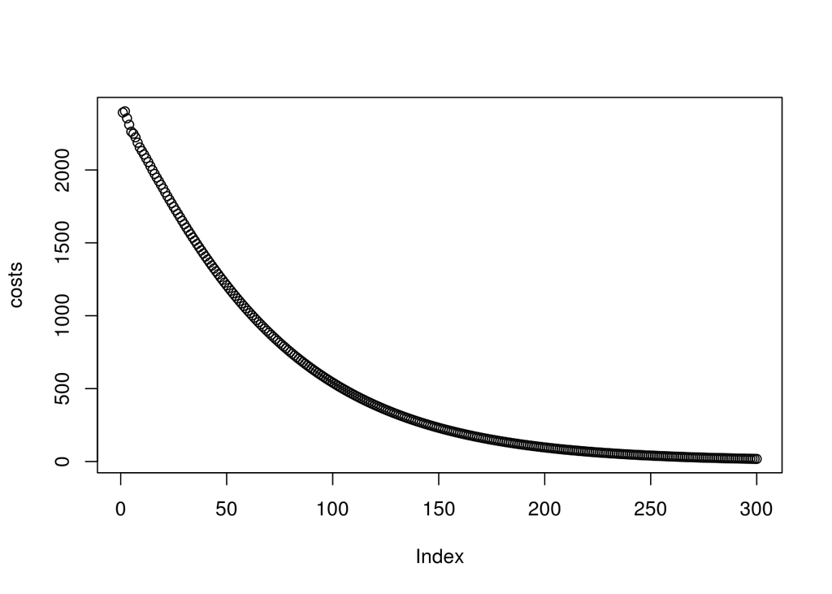

```
## [1] "Accuracy of training set: 0.99901670217514"
```

```r
## The accuracy for the test set
prediction_accuracy(test.log, test.cond, parameters.weights.dropout)
```

```
## [1] 0.9313725
```

```r
## Save the Tf Model
GERAS_Tf <- list(weight = parameters.weights.dropout, parameters.name = parameters.name, myTimePoints = myTimePoints, myTimePeriod = myTimePeriod, Age.labels = Age.labels)
saveRDS(object = GERAS_Tf, file = "GERAS_Tf_Hs_Final.rds")

## We will also save the test data for later use
saveRDS(list(test.log = test.log, test.cond = test.cond), file = "Hs_testSet.rds")
```